# Puffin

Hartaig Singh

September 8, 2017

Import Data Set

```r
puffin <- read.table("puffin.txt",header = T)
```

Multiple Linear Regression

```r
model1 <- lm(nesting~.,puffin)
summary(model1)
```

```
##
## Call:
## lm(formula = nesting ~ ., data = puffin)
##
## Residuals:
##     Min      1Q  Median      3Q     Max
## -4.0166 -2.1088  0.2293  1.2505  6.9881
##
## Coefficients:
##              Estimate Std. Error t value Pr(>|t|)
## (Intercept) 10.117840   3.185028   3.177  0.00323 **
## grass       -0.007408   0.019459  -0.381  0.70586
## soil         0.209211   0.077238   2.709  0.01062 *
## angle        0.082389   0.077796   1.059  0.29727
## distance    -0.366571   0.057473  -6.378 3.18e-07 ***
## ---
## Signif. codes:  0 '***' 0.001 '**' 0.01 '*' 0.05 '.' 0.1 ' ' 1
##
## Residual standard error: 2.647 on 33 degrees of freedom
## Multiple R-squared:  0.8792, Adjusted R-squared:  0.8645
## F-statistic: 60.03 on 4 and 33 DF,  p-value: 1.113e-14
```

**Interpretation** *Grass:* For every percent increase in grass covered, the number of nests for every 9m^2 decreases by .007 on average holding all other variables constant

*Soil:* For every cm increase in mean soil depth, the number of nests for every 9m^2 increases by .21 on average holding all other variables constant

*Angle:* For every degree increase in angle of slope, the number of nests for every 9m^2 increases by .082 on average holding all other variables constant

*Distance:* For every meter increase in distance from edge, the number of nests for every 9m^2 decreases by .367 on average holding all other variables constant

*R^2:* 87.92% of the variation in number of nests is explained by the predictors grass, soil, angle, and distance

Residual Plot

```r
pander(resid(model1))
```

Table continues below

| 1 | 2 | 3 | 4 | 5 | 6 | 7 | 8 | 9 | 10 | 11 |
| --- | --- | --- | --- | --- | --- | --- | --- | --- | --- | --- |
| -4.017 | -3.036 | 0.5395 | -2.866 | 0.6231 | -0.02855 | -1.346 | 0.01382 | 0.252 | 3.914 | -3.577 |

Table continues below

| 12 | 13 | 14 | 15 | 16 | 17 | 18 | 19 | 20 | 21 | 22 | 23 |
| --- | --- | --- | --- | --- | --- | --- | --- | --- | --- | --- | --- |
| 3.221 | 0.3239 | 0.579 | 2.807 | 1.289 | -2.358 | 0.9902 | 0.2065 | -2.119 | 6.988 | 1.102 | 1.137 |

Table continues below

| 24 | 25 | 26 | 27 | 28 | 29 | 30 | 31 | 32 | 33 | 34 | 35 |
| --- | --- | --- | --- | --- | --- | --- | --- | --- | --- | --- | --- |
| 3.743 | -2.124 | -3.046 | -1.898 | -1.624 | 0.6962 | 2.023 | -2.077 | 3.439 | 2.155 | -0.9509 | -3.495 |

| 36 | 37 | 38 |
| --- | --- | --- |
| -2.449 | -1.14 | 2.113 |

Studentized Residuals

```r
pander(rstandard(model1))
```

Table continues below

| 1 | 2 | 3 | 4 | 5 | 6 | 7 | 8 | 9 | 10 | 11 |
| --- | --- | --- | --- | --- | --- | --- | --- | --- | --- | --- |
| -1.636 | -1.252 | 0.2229 | -1.172 | 0.3004 | -0.01153 | -0.5365 | 0.005766 | 0.1062 | 1.631 | -1.45 |

Table continues below

| 12 | 13 | 14 | 15 | 16 | 17 | 18 | 19 | 20 | 21 | 22 |
| --- | --- | --- | --- | --- | --- | --- | --- | --- | --- | --- |
| 1.322 | 0.1331 | 0.2322 | 1.1 | 0.5054 | -0.9237 | 0.3964 | 0.08187 | -0.8473 | 2.866 | 0.4376 |

Table continues below

| 23 | 24 | 25 | 26 | 27 | 28 | 29 | 30 | 31 | 32 | 33 |
| --- | --- | --- | --- | --- | --- | --- | --- | --- | --- | --- |
| 0.4682 | 1.555 | -0.8382 | -1.191 | -0.7566 | -0.7054 | 0.285 | 0.826 | -0.8442 | 1.362 | 0.8399 |

| 34 | 35 | 36 | 37 | 38 |
| --- | --- | --- | --- | --- |
| -0.3717 | -1.355 | -0.9936 | -0.4626 | 0.8432 |

Deleted studentized residuals

```r
pander(rstudent(model1))
```

Table continues below

| 1 | 2 | 3 | 4 | 5 | 6 | 7 | 8 | 9 | 10 | 11 |
| --- | --- | --- | --- | --- | --- | --- | --- | --- | --- | --- |
| -1.681 | -1.263 | 0.2197 | -1.179 | 0.2962 | -0.01135 | -0.5306 | 0.005678 | 0.1045 | 1.675 | -1.476 |

Table continues below

| 12 | 13 | 14 | 15 | 16 | 17 | 18 | 19 | 20 | 21 | 22 |
| --- | --- | --- | --- | --- | --- | --- | --- | --- | --- | --- |
| 1.338 | 0.1311 | 0.2288 | 1.104 | 0.4996 | -0.9216 | 0.3913 | 0.08063 | -0.8436 | 3.256 | 0.4322 |

Table continues below

| 23 | 24 | 25 | 26 | 27 | 28 | 29 | 30 | 31 | 32 | 33 |
| --- | --- | --- | --- | --- | --- | --- | --- | --- | --- | --- |
| 0.4626 | 1.59 | -0.8343 | -1.199 | -0.7516 | -0.6999 | 0.281 | 0.822 | -0.8405 | 1.38 | 0.8361 |

| 34 | 35 | 36 | 37 | 38 |
| --- | --- | --- | --- | --- |
| -0.3668 | -1.373 | -0.9934 | -0.457 | 0.8394 |

Difference between studentized residuals and deleted studentized residual

```r
pander(rstandard(model1)-rstudent(model1))
```

Table continues below

| 1 | 2 | 3 | 4 | 5 | 6 | 7 | 8 | 9 |
| --- | --- | --- | --- | --- | --- | --- | --- | --- |
| 0.04462 | 0.01125 | 0.003238 | 0.00692 | 0.004181 | -0.000176 | -0.005872 | 8.803e-05 | 0.001603 |

Table continues below

| 10 | 11 | 12 | 13 | 14 | 15 | 16 | 17 | 18 |
| --- | --- | --- | --- | --- | --- | --- | --- | --- |
| -0.04407 | 0.02564 | -0.01575 | 0.001997 | 0.003358 | -0.003646 | 0.005779 | -0.00211 | 0.00512 |

Table continues below

| 19 | 20 | 21 | 22 | 23 | 24 | 25 | 26 |
| --- | --- | --- | --- | --- | --- | --- | --- |
| 0.001242 | -0.003709 | -0.3903 | 0.005426 | 0.00561 | -0.03561 | -0.003868 | 0.007865 |

Table continues below

| 27 | 28 | 29 | 30 | 31 | 32 | 33 | 34 |
| --- | --- | --- | --- | --- | --- | --- | --- |
| -0.005004 | -0.005473 | 0.004006 | 0.00407 | -0.003764 | -0.01856 | 0.003839 | -0.004906 |

| 35 | 36 | 37 | 38 |
| --- | --- | --- | --- |
| 0.01808 | -0.0001975 | -0.005579 | 0.003782 |

```r
which.max(abs(rstandard(model1)-rstudent(model1)))
```

```
## 21
## 21
```

Obersvation 21 has the largest difference between studentized residuals and deleted studentized residuals. This means that observation 21 may be influential since its presence changes the predicted value the most in the data set.

DFFITS

```r
pander(dffits(model1))
```

Table continues below

| 1 | 2 | 3 | 4 | 5 | 6 | 7 | 8 | 9 | 10 |
| --- | --- | --- | --- | --- | --- | --- | --- | --- | --- |
| -0.6783 | -0.5528 | 0.09744 | -0.49 | 0.2349 | -0.00429 | -0.1793 | 0.002658 | 0.05164 | 0.7819 |

Table continues below

| 11 | 12 | 13 | 14 | 15 | 16 | 17 | 18 | 19 | 20 | 21 |
| --- | --- | --- | --- | --- | --- | --- | --- | --- | --- | --- |
| -0.5743 | 0.5704 | 0.05631 | 0.08146 | 0.307 | 0.1398 | -0.2531 | 0.1375 | 0.02565 | -0.2928 | 1.376 |

Table continues below

| 22 | 23 | 24 | 25 | 26 | 27 | 28 | 29 | 30 | 31 | 32 |
| --- | --- | --- | --- | --- | --- | --- | --- | --- | --- | --- |
| 0.1402 | 0.2014 | 0.728 | -0.252 | -0.3207 | -0.2538 | -0.3969 | 0.1174 | 0.3372 | -0.3338 | 0.4351 |

| 33 | 34 | 35 | 36 | 37 | 38 |
| --- | --- | --- | --- | --- | --- |
| 0.212 | -0.09754 | -0.3187 | -0.3891 | -0.1789 | 0.2859 |

```r
which(dffits(model1)>3*sqrt((4+1)/(38-4-1)))
```

```
## 21
## 21
```

Observation 21 has DFFIT greater than the specified cutoff

DFBETAS

```r
pander(dfbetas(model1))
```

| (Intercept) | grass | soil | angle | distance |
| --- | --- | --- | --- | --- |
| -0.01093 | 0.1657 | -0.09175 | -0.1774 | 0.1149 |
| 0.3011 | -0.07463 | -0.2214 | -0.2213 | -0.03991 |
| 0.09102 | -0.03404 | -0.04801 | -0.02994 | -0.0349 |
| -0.414 | 0.3619 | 0.06742 | 0.1929 | 0.235 |
| 0.06231 | -0.1326 | 0.1861 | -0.1967 | -0.1941 |
| 0.001597 | -0.0008566 | -0.003145 | 0.001679 | 0.001266 |
| 0.06454 | -0.05245 | -0.1094 | 0.06246 | 0.03367 |
| 0.00129 | -0.000987 | -0.001661 | 0.0005461 | 0.0009242 |
| 0.001101 | -0.03489 | 0.00891 | 0.00137 | 0.008811 |
| -0.0616 | -0.156 | -0.2614 | 0.3175 | 0.508 |
| -0.2833 | 0.2795 | -0.05788 | 0.0979 | 0.3088 |
| -0.2889 | 0.06572 | 0.1522 | 0.2914 | 0.09499 |
| -0.008826 | 0.0443 | -0.03031 | 0.03066 | 0.02399 |
| 0.07207 | -0.01563 | -0.04369 | -0.02445 | -0.02271 |
| 0.08476 | 0.1736 | -0.1392 | -0.01256 | 0.02248 |
| 0.01455 | 0.05393 | 0.02046 | -0.06254 | -0.03208 |
| -0.1245 | -0.04313 | 0.1401 | 0.02778 | -0.03621 |
| 0.009377 | 0.06688 | -0.07885 | 0.02748 | 0.07053 |
| -0.003386 | -0.003321 | -0.006479 | 0.009794 | 0.0159 |
| 0.01208 | -0.02724 | 0.03083 | -0.1274 | -0.006827 |
| -0.6565 | 0.01514 | 0.6673 | 0.4045 | -0.05444 |
| -0.009833 | 0.09775 | -0.06549 | 0.06326 | 0.04153 |
| 0.00214 | 0.03255 | 0.1255 | -0.1253 | -0.1298 |
| 0.6236 | -0.5518 | 0.00452 | -0.444 | -0.4312 |
| -0.057 | -0.1334 | 0.04681 | 0.07246 | 0.02657 |
| -0.1104 | 0.2024 | -0.03143 | 0.081 | 0.02282 |
| 0.1364 | -0.09825 | -0.1026 | 0.01008 | -0.05411 |
| 0.1119 | 0.2182 | -0.2582 | 0.06258 | 0.01528 |
| 0.02783 | -0.01857 | -0.04603 | 0.05548 | 0.01278 |
| 0.00568 | -0.0419 | -0.09189 | 0.1969 | 0.07311 |
| -0.1727 | -0.1249 | 0.08469 | 0.1302 | 0.1291 |
| 0.2162 | 0.09913 | -0.005252 | -0.2486 | -0.2241 |
| -0.01514 | 0.08518 | 0.07161 | -0.0763 | -0.06001 |
| -0.02277 | -0.0499 | 0.04272 | 0.004368 | -0.0164 |
| 0.1307 | -0.1355 | 0.005462 | -0.08948 | -0.1587 |
| 0.2277 | -0.2785 | 0.1062 | -0.2403 | -0.2991 |
| 0.1096 | -0.04359 | 0.01727 | -0.1165 | -0.1429 |
| -0.1097 | 0.03235 | 0.00693 | 0.0651 | 0.1601 |

Removing observation 21 would decrease the coefficients for grass, soil, angle, and increase for distance

To generalize, if an observation has a positive DFBETA, removing the observation would decrease the beta value. The opposite holds for a negative DFBETA.

Measures of Influence

```r
pander(influence.measures(model1))
```

- **infmat**:

  Table continues below

  | dfb.1_ | dfb.grss | dfb.soil | dfb.angl | dfb.dstn | dffit | cov.r | cook.d |
  | --- | --- | --- | --- | --- | --- | --- | --- |
  | -0.01093 | 0.1657 | -0.09175 | -0.1774 | 0.1149 | -0.6783 | 0.8885 | 0.0872 |
  | 0.3011 | -0.07463 | -0.2214 | -0.2213 | -0.03991 | -0.5528 | 1.09 | 0.06003 |
  | 0.09102 | -0.03404 | -0.04801 | -0.02994 | -0.0349 | 0.09744 | 1.385 | 0.001955 |
  | -0.414 | 0.3619 | 0.06742 | 0.1929 | 0.235 | -0.49 | 1.106 | 0.04745 |
  | 0.06231 | -0.1326 | 0.1861 | -0.1967 | -0.1941 | 0.2349 | 1.874 | 0.01135 |
  | 0.001597 | -0.0008566 | -0.003145 | 0.001679 | 0.001266 | -0.00429 | 1.333 | 3.796e-06 |
  | 0.06454 | -0.05245 | -0.1094 | 0.06246 | 0.03367 | -0.1793 | 1.244 | 0.00657 |
  | 0.00129 | -0.000987 | -0.001661 | 0.0005461 | 0.0009242 | 0.002658 | 1.422 | 1.457e-06 |
  | 0.001101 | -0.03489 | 0.00891 | 0.00137 | 0.008811 | 0.05164 | 1.448 | 0.0005498 |
  | -0.0616 | -0.156 | -0.2614 | 0.3175 | 0.508 | 0.7819 | 0.9328 | 0.1159 |
  | -0.2833 | 0.2795 | -0.05788 | 0.0979 | 0.3088 | -0.5743 | 0.9663 | 0.0637 |
  | -0.2889 | 0.06572 | 0.1522 | 0.2914 | 0.09499 | 0.5704 | 1.05 | 0.06355 |
  | -0.008826 | 0.0443 | -0.03031 | 0.03066 | 0.02399 | 0.05631 | 1.378 | 0.0006537 |
  | 0.07207 | -0.01563 | -0.04369 | -0.02445 | -0.02271 | 0.08146 | 1.303 | 0.001367 |
  | 0.08476 | 0.1736 | -0.1392 | -0.01256 | 0.02248 | 0.307 | 1.042 | 0.01872 |
  | 0.01455 | 0.05393 | 0.02046 | -0.06254 | -0.03208 | 0.1398 | 1.21 | 0.004002 |
  | -0.1245 | -0.04313 | 0.1401 | 0.02778 | -0.03621 | -0.2531 | 1.1 | 0.01287 |
  | 0.009377 | 0.06688 | -0.07885 | 0.02748 | 0.07053 | 0.1375 | 1.279 | 0.00388 |
  | -0.003386 | -0.003321 | -0.006479 | 0.009794 | 0.0159 | 0.02565 | 1.283 | 0.0001356 |
  | 0.01208 | -0.02724 | 0.03083 | -0.1274 | -0.006827 | -0.2928 | 1.171 | 0.0173 |
  | -0.6565 | 0.01514 | 0.6673 | 0.4045 | -0.05444 | 1.376 | 0.3287 | 0.2933 |
  | -0.009833 | 0.09775 | -0.06549 | 0.06326 | 0.04153 | 0.1402 | 1.252 | 0.004031 |
  | 0.00214 | 0.03255 | 0.1255 | -0.1253 | -0.1298 | 0.2014 | 1.342 | 0.008308 |
  | 0.6236 | -0.5518 | 0.00452 | -0.444 | -0.4312 | 0.728 | 0.9644 | 0.1013 |
  | -0.057 | -0.1334 | 0.04681 | 0.07246 | 0.02657 | -0.252 | 1.143 | 0.01282 |
  | -0.1104 | 0.2024 | -0.03143 | 0.081 | 0.02282 | -0.3207 | 1.003 | 0.02031 |
  | 0.1364 | -0.09825 | -0.1026 | 0.01008 | -0.05411 | -0.2538 | 1.19 | 0.01306 |
  | 0.1119 | 0.2182 | -0.2582 | 0.06258 | 0.01528 | -0.3969 | 1.429 | 0.032 |
  | 0.02783 | -0.01857 | -0.04603 | 0.05548 | 0.01278 | 0.1174 | 1.353 | 0.002836 |
  | 0.00568 | -0.0419 | -0.09189 | 0.1969 | 0.07311 | 0.3372 | 1.227 | 0.02297 |
  | -0.1727 | -0.1249 | 0.08469 | 0.1302 | 0.1291 | -0.3338 | 1.211 | 0.02248 |
  | 0.2162 | 0.09913 | -0.005252 | -0.2486 | -0.2241 | 0.4351 | 0.9601 | 0.03684 |
  | -0.01514 | 0.08518 | 0.07161 | -0.0763 | -0.06001 | 0.212 | 1.114 | 0.009073 |
  | -0.02277 | -0.0499 | 0.04272 | 0.004368 | -0.0164 | -0.09754 | 1.223 | 0.001954 |
  | 0.1307 | -0.1355 | 0.005462 | -0.08948 | -0.1587 | -0.3187 | 0.923 | 0.01978 |
  | 0.2277 | -0.2785 | 0.1062 | -0.2403 | -0.2991 | -0.3891 | 1.156 | 0.0303 |
  | 0.1096 | -0.04359 | 0.01727 | -0.1165 | -0.1429 | -0.1789 | 1.302 | 0.00656 |
  | -0.1097 | 0.03235 | 0.00693 | 0.0651 | 0.1601 | 0.2859 | 1.167 | 0.0165 |

  | hat |
  | --- |
  | 0.1401 |
  | 0.1607 |
  | 0.1644 |
  | 0.1472 |
  | 0.3861 |
  | 0.125 |
  | 0.1024 |
  | 0.1798 |
  | 0.1961 |
  | 0.1788 |
  | 0.1316 |
  | 0.1537 |
  | 0.1557 |
  | 0.1125 |
  | 0.07175 |
  | 0.07265 |
  | 0.07013 |
  | 0.1099 |
  | 0.09188 |
  | 0.1075 |
  | 0.1515 |
  | 0.09523 |
  | 0.1593 |
  | 0.1732 |
  | 0.08358 |
  | 0.0668 |
  | 0.1024 |
  | 0.2433 |
  | 0.1486 |
  | 0.1441 |
  | 0.1362 |
  | 0.09035 |
  | 0.06042 |
  | 0.06605 |
  | 0.05109 |
  | 0.133 |
  | 0.1329 |
  | 0.1039 |

- **is.inf**:

  | dfb.1_ | dfb.grss | dfb.soil | dfb.angl | dfb.dstn | dffit | cov.r | cook.d | hat |
  | --- | --- | --- | --- | --- | --- | --- | --- | --- |
  | FALSE | FALSE | FALSE | FALSE | FALSE | FALSE | FALSE | FALSE | FALSE |
  | FALSE | FALSE | FALSE | FALSE | FALSE | FALSE | FALSE | FALSE | FALSE |
  | FALSE | FALSE | FALSE | FALSE | FALSE | FALSE | FALSE | FALSE | FALSE |
  | FALSE | FALSE | FALSE | FALSE | FALSE | FALSE | FALSE | FALSE | FALSE |
  | FALSE | FALSE | FALSE | FALSE | FALSE | FALSE | TRUE | FALSE | FALSE |
  | FALSE | FALSE | FALSE | FALSE | FALSE | FALSE | FALSE | FALSE | FALSE |
  | FALSE | FALSE | FALSE | FALSE | FALSE | FALSE | FALSE | FALSE | FALSE |
  | FALSE | FALSE | FALSE | FALSE | FALSE | FALSE | FALSE | FALSE | FALSE |
  | FALSE | FALSE | FALSE | FALSE | FALSE | FALSE | FALSE | FALSE | FALSE |
  | FALSE | FALSE | FALSE | FALSE | FALSE | FALSE | FALSE | FALSE | FALSE |
  | FALSE | FALSE | FALSE | FALSE | FALSE | FALSE | FALSE | FALSE | FALSE |
  | FALSE | FALSE | FALSE | FALSE | FALSE | FALSE | FALSE | FALSE | FALSE |
  | FALSE | FALSE | FALSE | FALSE | FALSE | FALSE | FALSE | FALSE | FALSE |
  | FALSE | FALSE | FALSE | FALSE | FALSE | FALSE | FALSE | FALSE | FALSE |
  | FALSE | FALSE | FALSE | FALSE | FALSE | FALSE | FALSE | FALSE | FALSE |
  | FALSE | FALSE | FALSE | FALSE | FALSE | FALSE | FALSE | FALSE | FALSE |
  | FALSE | FALSE | FALSE | FALSE | FALSE | FALSE | FALSE | FALSE | FALSE |
  | FALSE | FALSE | FALSE | FALSE | FALSE | FALSE | FALSE | FALSE | FALSE |
  | FALSE | FALSE | FALSE | FALSE | FALSE | FALSE | FALSE | FALSE | FALSE |
  | FALSE | FALSE | FALSE | FALSE | FALSE | FALSE | FALSE | FALSE | FALSE |
  | FALSE | FALSE | FALSE | FALSE | FALSE | TRUE | TRUE | FALSE | FALSE |
  | FALSE | FALSE | FALSE | FALSE | FALSE | FALSE | FALSE | FALSE | FALSE |
  | FALSE | FALSE | FALSE | FALSE | FALSE | FALSE | FALSE | FALSE | FALSE |
  | FALSE | FALSE | FALSE | FALSE | FALSE | FALSE | FALSE | FALSE | FALSE |
  | FALSE | FALSE | FALSE | FALSE | FALSE | FALSE | FALSE | FALSE | FALSE |
  | FALSE | FALSE | FALSE | FALSE | FALSE | FALSE | FALSE | FALSE | FALSE |
  | FALSE | FALSE | FALSE | FALSE | FALSE | FALSE | FALSE | FALSE | FALSE |
  | FALSE | FALSE | FALSE | FALSE | FALSE | FALSE | FALSE | FALSE | FALSE |
  | FALSE | FALSE | FALSE | FALSE | FALSE | FALSE | FALSE | FALSE | FALSE |
  | FALSE | FALSE | FALSE | FALSE | FALSE | FALSE | FALSE | FALSE | FALSE |
  | FALSE | FALSE | FALSE | FALSE | FALSE | FALSE | FALSE | FALSE | FALSE |
  | FALSE | FALSE | FALSE | FALSE | FALSE | FALSE | FALSE | FALSE | FALSE |
  | FALSE | FALSE | FALSE | FALSE | FALSE | FALSE | FALSE | FALSE | FALSE |
  | FALSE | FALSE | FALSE | FALSE | FALSE | FALSE | FALSE | FALSE | FALSE |
  | FALSE | FALSE | FALSE | FALSE | FALSE | FALSE | FALSE | FALSE | FALSE |
  | FALSE | FALSE | FALSE | FALSE | FALSE | FALSE | FALSE | FALSE | FALSE |
  | FALSE | FALSE | FALSE | FALSE | FALSE | FALSE | FALSE | FALSE | FALSE |
  | FALSE | FALSE | FALSE | FALSE | FALSE | FALSE | FALSE | FALSE | FALSE |

- **call**: `lm(formula = nesting ~ ., data = puffin)`

Observations 5 and 21 are flagged as being influential

Outlier Analysis

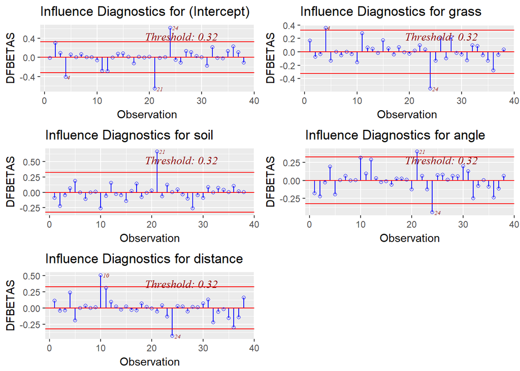

```r
ols_dfbetas_panel(model1)
```

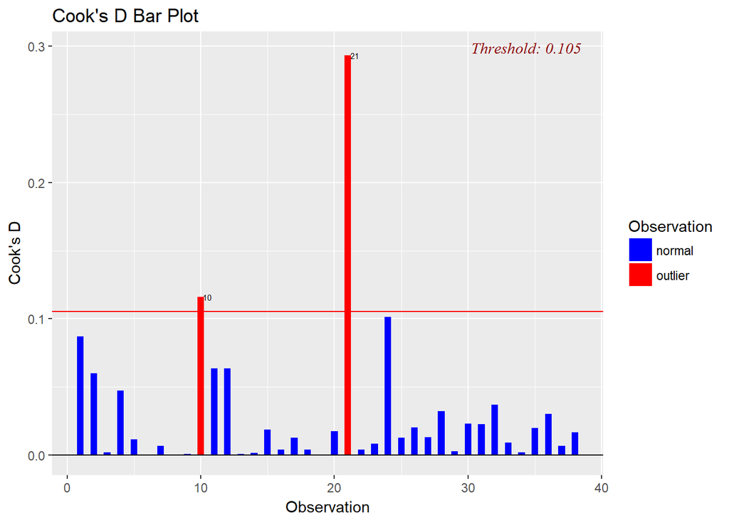

```r
ols_cooksd_barplot(model1)
```

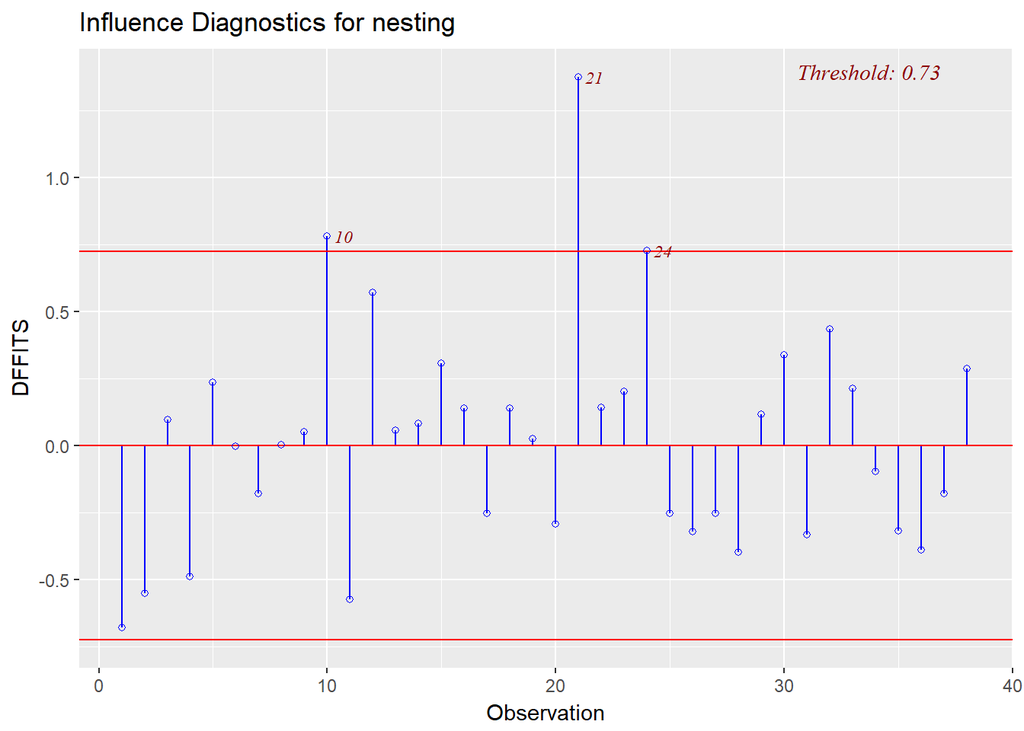

```r
ols_dffits_plot(model1)
```

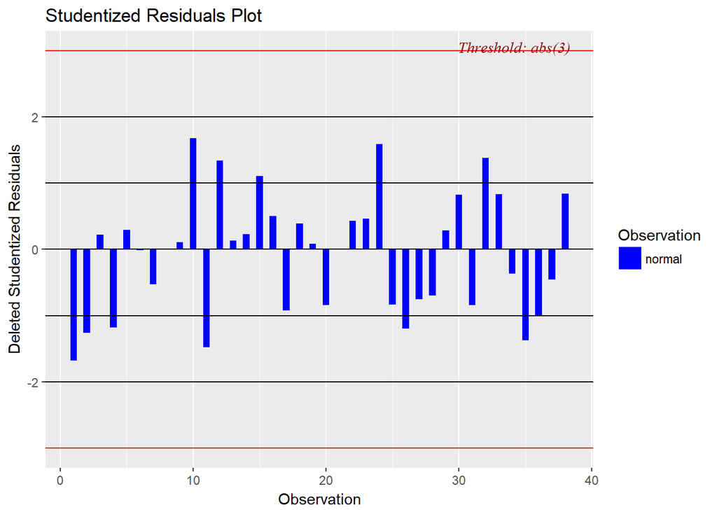

```r
ols_srsd_plot(model1)
```

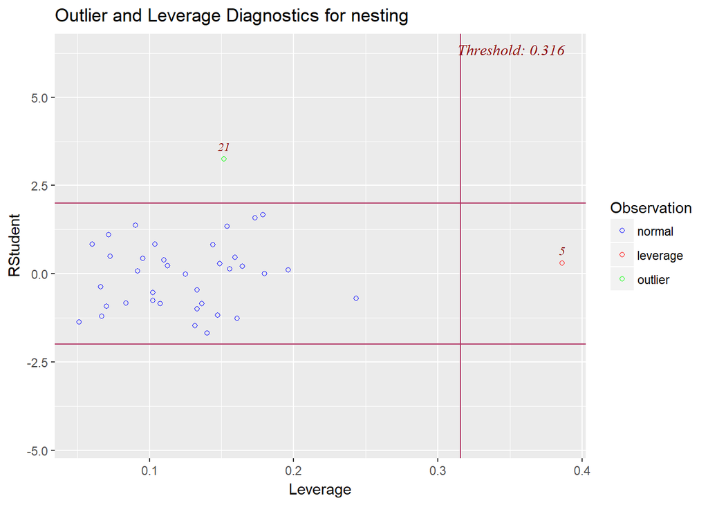

```r
ols_rsdlev_plot(model1)
```

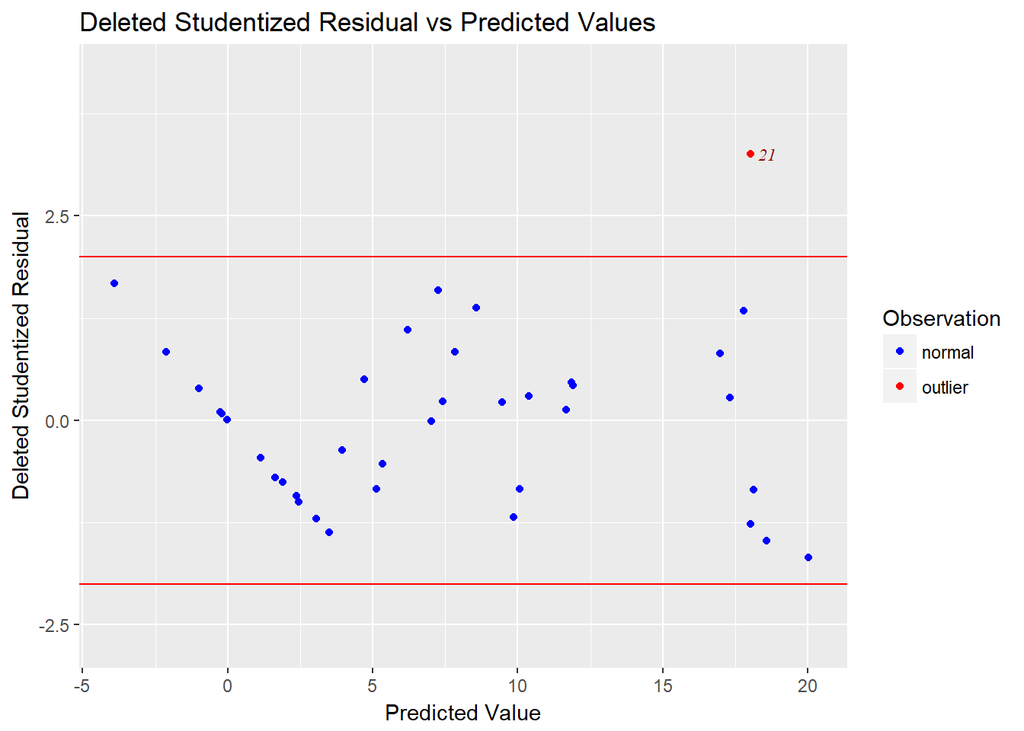

```r
ols_dsrvsp_plot(model1)
```

I would consider observations 5, 21, 10, 24 as influential because observation 24 has fairly high DFBETAS for grass, angle, and distance and borderline high DFFITS

Observation 10 has high DFBETA for distance, high cooks distance, and high DFFITS

Observation 5 also has high leverage